# Taller 3

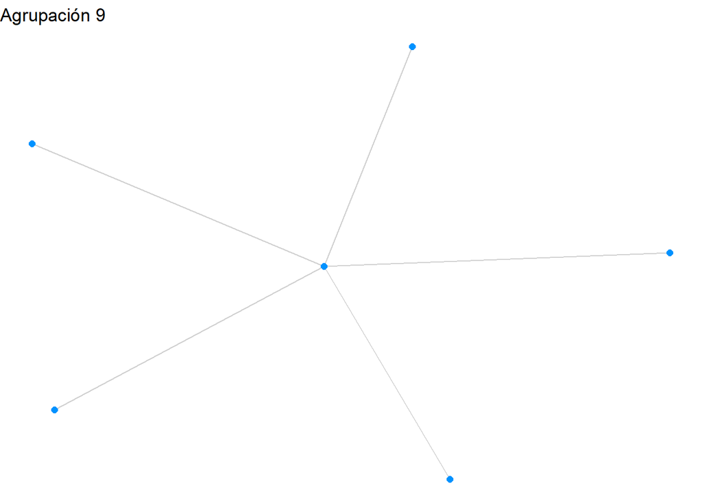

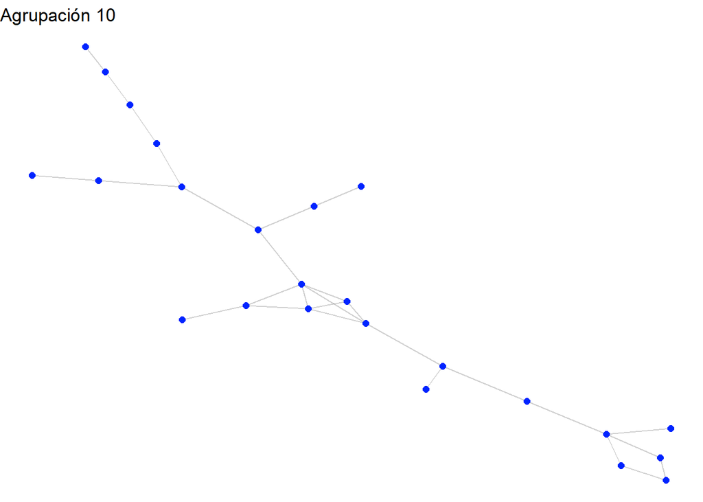

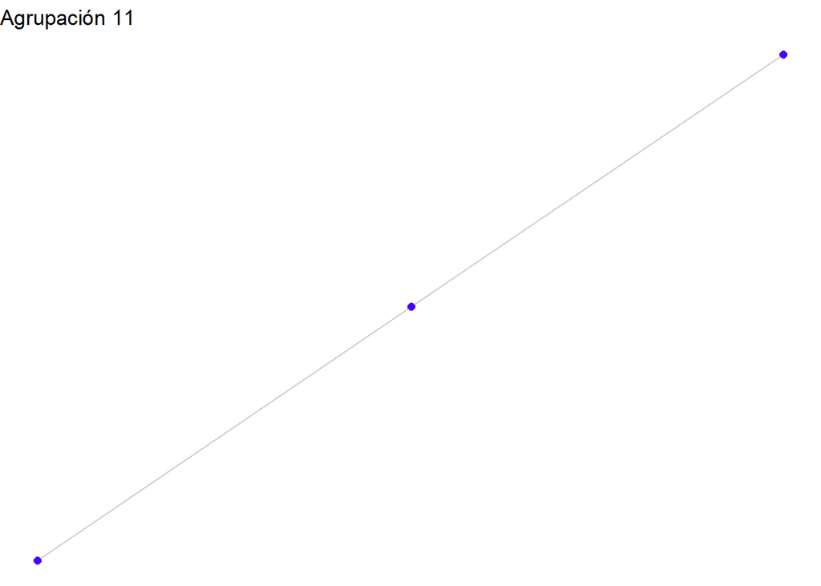

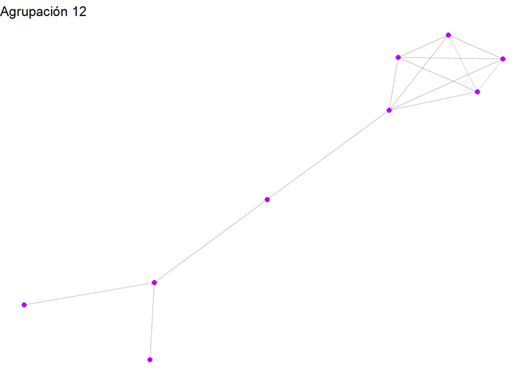

[2 more figures not shown]

La red de trabajo presenta un número de comunidades similar al observado en la red de alianzas bajo el algoritmo de Fast Greedy, lo que sugiere una segmentación estructural comparable entre ambos tipos de relaciones.

# 4. Considere el conjunto de datos disponible en el archivo traders.RData (139 KB). Este archivo contiene un arreglo de dimensión $T\times I\times I$, donde se registran datos relacionales de $I$ comerciantes (traders) a lo largo de $T$ semanas. Este conjunto consta de $T=201$ redes binarias dirigidas de tamaño $I=71$, representando las transacciones en el mercado de futuros de gas natural en la Bolsa Mercantil de Nueva York (NYMEX) durante el período de enero de 2005 a diciembre de 2008. Cada red semanal establece un vínculo dirigido entre un comerciante $A$ y un comerciante $B$ si hubo al menos una transacción en la que $A$ actuó como vendedor y $B$ como comprador (Betancourt et al., 2020). Hasta el 5 de septiembre de 2006 (semana 83), los futuros de gas natural se negociaron exclusivamente mediante operaciones tradicionales a gritos. A partir de esa fecha, se introdujo una plataforma de negociación electrónica como método alternativo. Este caso de estudio tiene como objetivo investigar si la implementación de esta plataforma provocó un cambio estructural significativo en el mercado de futuros de gas natural (Betancourt, B., Rodríguez, A., & Boyd, N. (2020). Modelling and prediction of financial trading networks: An application to the New York Mercantile Exchange natural gas futures market. Journal of the Royal Statistical Society Series C: Applied Statistics, 69(1)).

## a. Para cada red en cada semana, calcular métricas clave como la densidad, el coeficiente de agrupamiento, la asortatividad, la reciprocidad, la distancia geodésica promedio, el tamaño de la componente gigante, el grado de salida promedio y el grado de entrada promedio. Representar las series de tiempo generadas para cada métrica, incorporando una línea vertical en la semana 83, una línea horizontal en la mediana de los valores de la serie antes de la semana 83 (inclusive) y otra línea horizontal en la mediana de los valores posteriores a esta semana. Además, aplicar la prueba de Mann-Whitney para comparar los valores de cada serie antes y después de la semana 83. Presentar los resultados de estas comparaciones en una tabla, indicando las diferencias estadísticas identificadas.

## Densidad

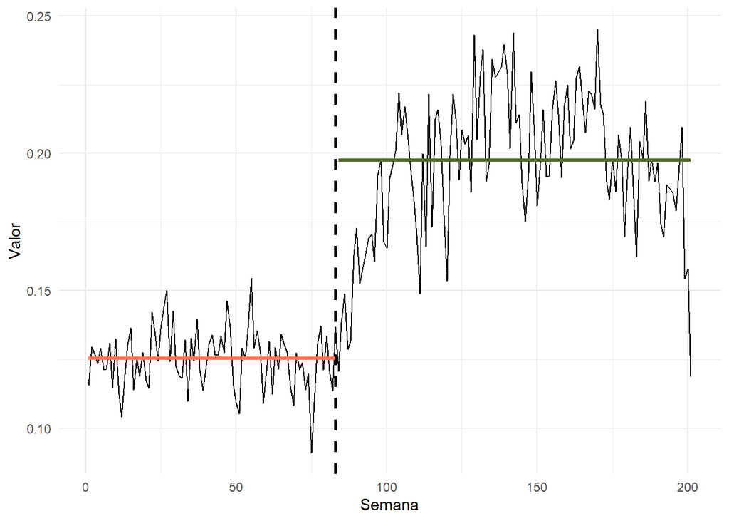

Prueba de Mann-Whitney y medidas descriptivas. p = 4.42e-31

| Grupo | Mediana | Desv. Estándar |
| --- | --- | --- |
| Semana ≤ 83 | 0.13 | 0.01 |
| Semana > 83 | 0.20 | 0.03 |

## Coeficiente de agrupamiento

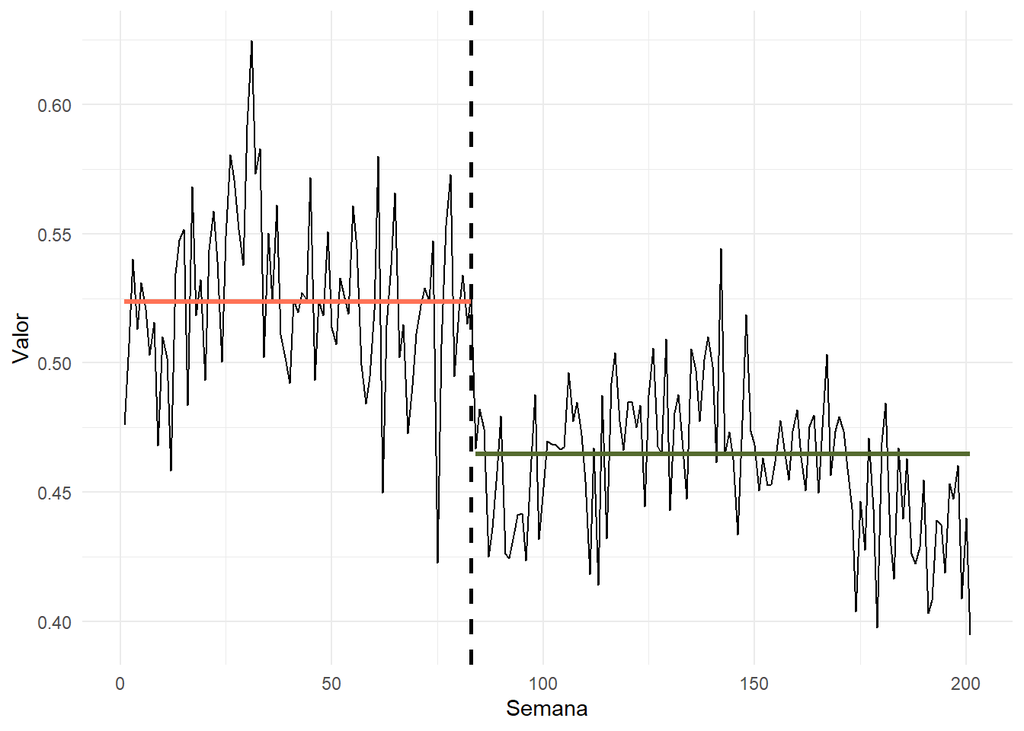

Prueba de Mann-Whitney y medidas descriptivas. p = 0

| Grupo | Mediana | Desv. Estándar |
| --- | --- | --- |
| Semana ≤ 83 | 0.52 | 0.03 |
| Semana > 83 | 0.46 | 0.03 |

También notamos un cambio pues el coeficiente de agrupamiento antes era de 0.52, luego bajo a 0.46 manteniendo la variabilidad. Esto sugiere una disminución moderada en la cohesión local de las interacciones, evidenciando que las relaciones entre agentes tienden a ser menos redundantes en términos de conexiones compartidas.

## Asortatividad

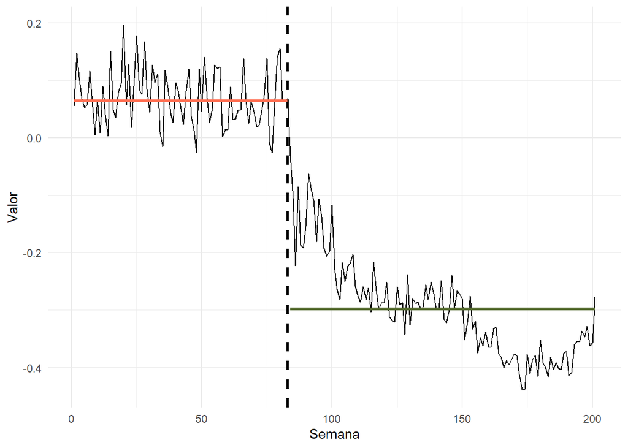

Prueba de Mann-Whitney y medidas descriptivas. p = 0

| Grupo | Mediana | Desv. Estándar |
| --- | --- | --- |
| Semana ≤ 83 | 0.06 | 0.05 |
| Semana > 83 | -0.30 | 0.09 |

Se observa una disminución en la asortatividad de la red, pasando de valores cercanos a 0.06 en el periodo inicial a valores negativos alrededor de -0.30 en el periodo posterior a la implementación de la plataforma electrónica. Esto nos indica que antes del aplicativo había más tendencia a conectar con comerciantes con más conexiones, pero ahora la tendencia cambio, y ya conectan con comerciantes con pocas conexiones.

## Reciprocidad

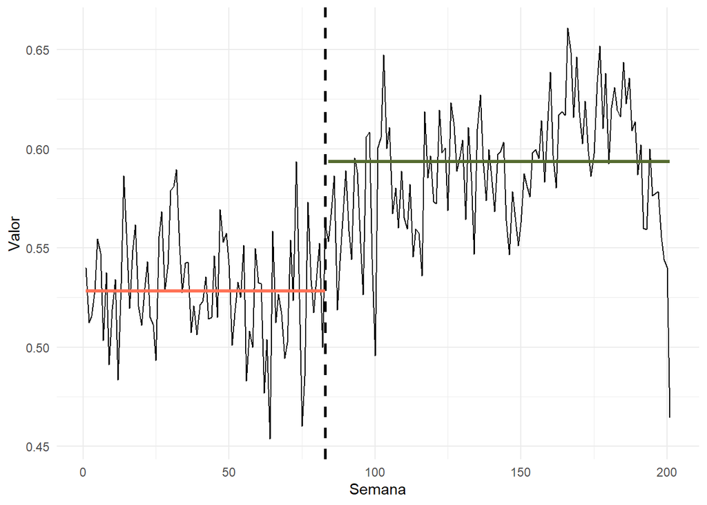

Prueba de Mann-Whitney y medidas descriptivas. p = 3.69e-24

| Grupo | Mediana | Desv. Estándar |
| --- | --- | --- |
| Semana ≤ 83 | 0.53 | 0.03 |
| Semana > 83 | 0.59 | 0.03 |

Se evidencia un leve aumento de 0.53 a 0.59, manteniendo la variabilidad. Este resultado indica un incremento en la tendencia de las relaciones a ser bidireccionales, es decir, una mayor probabilidad de que una transacción entre dos agentes sea correspondida en sentido inverso.

## Distancia geodésica promedio

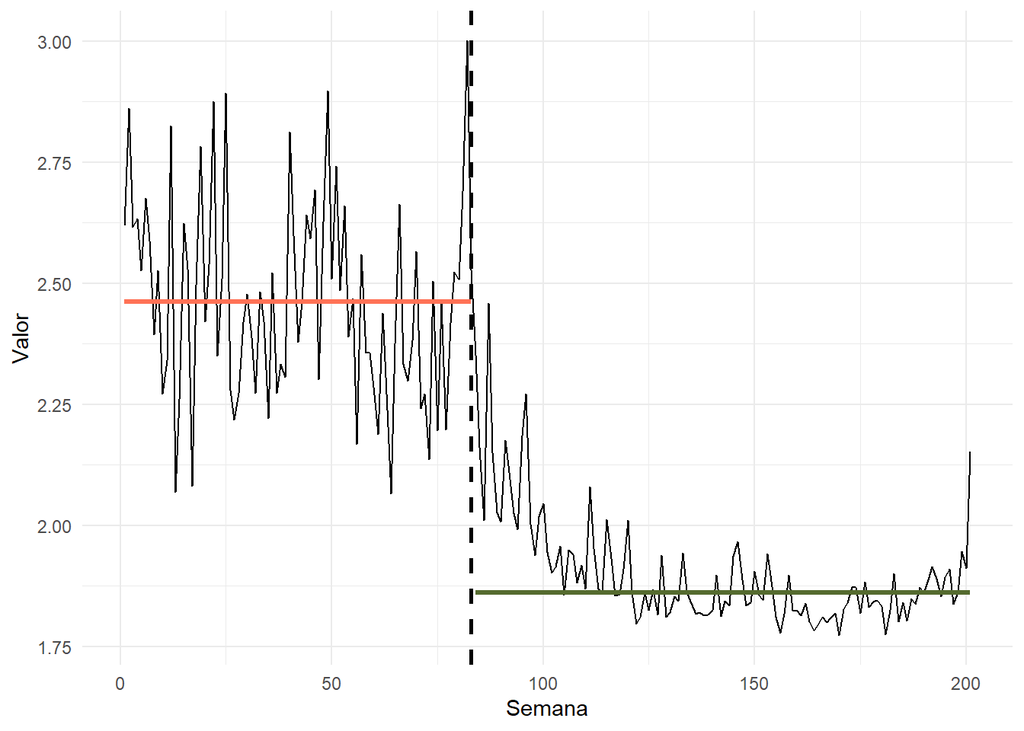

Prueba de Mann-Whitney y medidas descriptivas. p = 0

| Grupo | Mediana | Desv. Estándar |
| --- | --- | --- |
| Semana ≤ 83 | 2.46 | 0.21 |
| Semana > 83 | 1.86 | 0.12 |

## Tamaño componente gigante

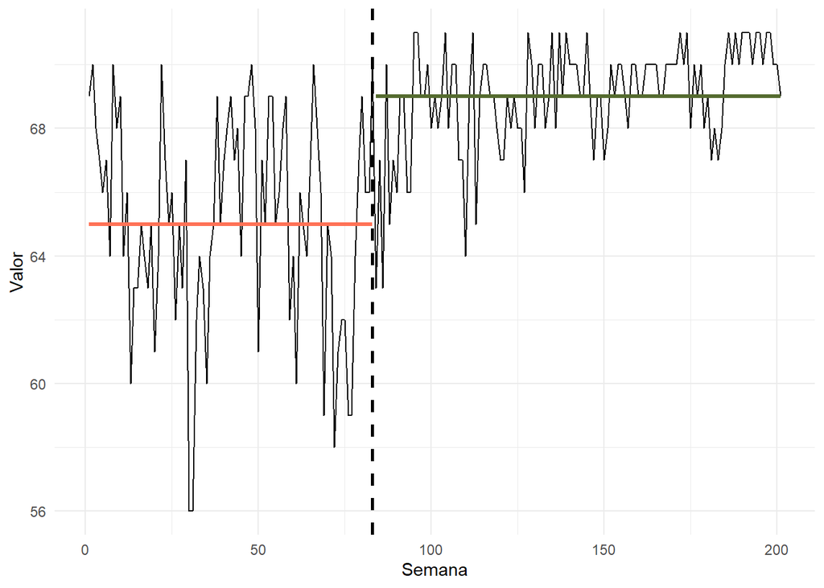

Prueba de Mann-Whitney y medidas descriptivas. p = 4.96e-18

| Grupo | Mediana | Desv. Estándar |
| --- | --- | --- |
| Semana ≤ 83 | 65 | 3.37 |
| Semana > 83 | 69 | 1.69 |

Hubo un leve aumento en el tamaño de la componente gigante, sin embargo se resalta más la disminución de la variabilidad de estos, pues antes del aplicativo tenía una desviaición estándar de 3.37 y despues de este presentó una desviación estándar de 1.69, haciendo más estable las redes despues del aplicativo.

## Grado de salida y grado de entrada

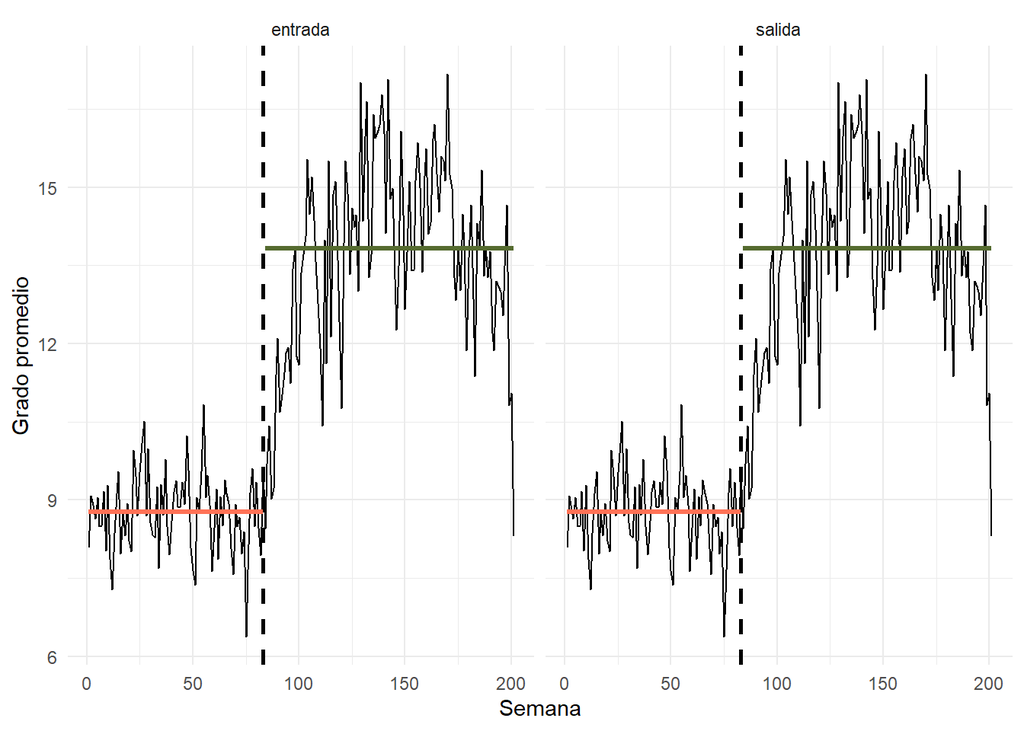

| Grupo | Mediana | Desv. Estándar |
| --- | --- | --- |
| Semana ≤ 83 | 8.77 | 0.77 |
| Semana > 83 | 13.82 | 1.88 |

| Grupo | Mediana | Desv. Estándar |
| --- | --- | --- |
| Semana ≤ 83 | 8.77 | 0.77 |
| Semana > 83 | 13.82 | 1.88 |

En conjunto, estos resultados evidencian una transformación significativa tanto en el nivel como en la dispersión de la estructura del sistema.

## Número de grupos

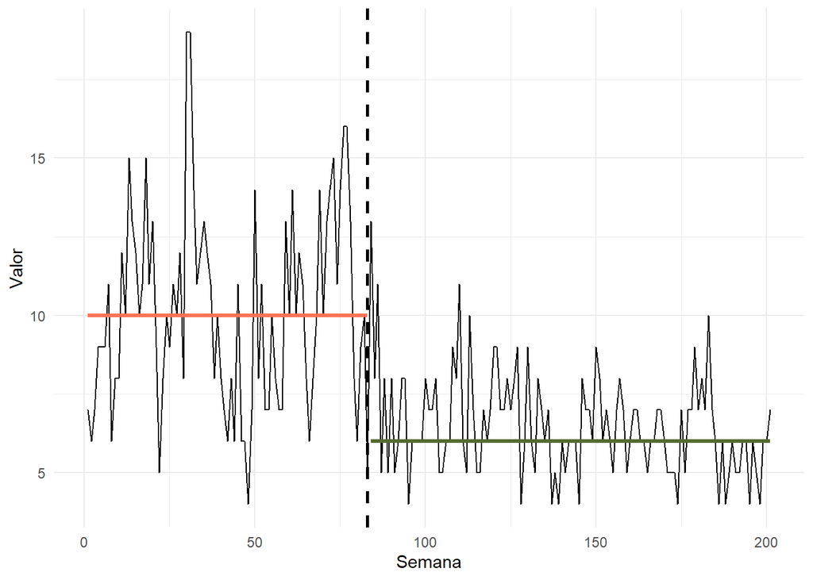

Prueba de Mann-Whitney y medidas descriptivas. p = 0

| Grupo | Mediana | Desv. Estándar |
| --- | --- | --- |
| Semana ≤ 83 | 10 | 3.19 |
| Semana > 83 | 6 | 1.63 |

Se evidencia una disminución del número de grupos, pero también se ve una disminución en la variabilidad, lo que deja claro que las comunidades se fusionaron en estructuras más grandes, y estructuralmente más estables.

## Modularidad

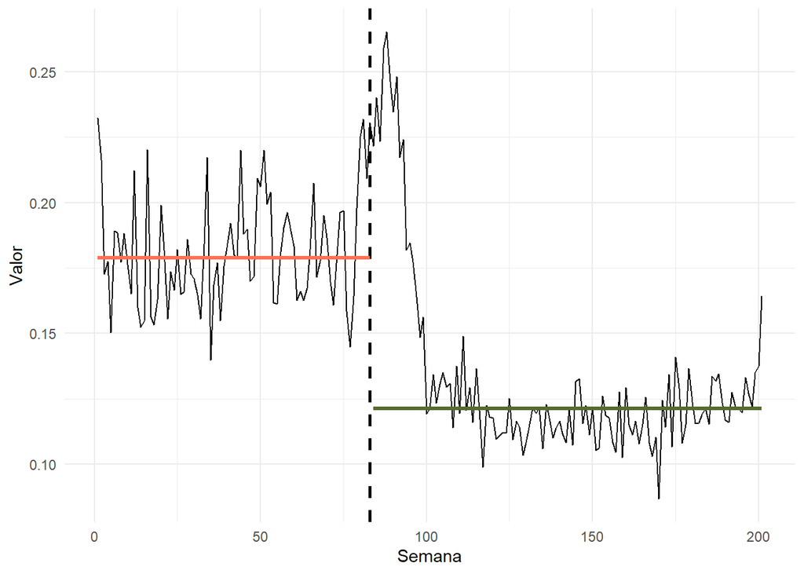

Prueba de Mann-Whitney y medidas descriptivas. p = 0

| Grupo | Mediana | Desv. Estándar |
| --- | --- | --- |
| Semana ≤ 83 | 0.18 | 0.02 |
| Semana > 83 | 0.12 | 0.04 |

Se observa una disminución al comparar las semanas alrededor del punto de cambio, mientras que antes de la semana 83 se obtiene un valor aproximado de 0.18, en las semanas posteriores este desciende a valores cercanos a 0.12. Esta reducción no implica la ausencia de comunidades, sino que sugiere que, aunque continúan existiendo agrupamientos entre los comerciantes, estos presentan fronteras menos definidas y una mayor interconexión entre grupos.

En términos generales, estos hallazgos indican que, después de la implementación de la plataforma electrónica, el mercado se reestructuró: se redujo la fragmentación que existía antes y se adoptó una configuración más estable, pero con comunidades que muestran una separación menos marcada que en el período previo.

## c. Sea $Y_t=[y_{i,j,t}]$ la matriz de adyacencia de dimensión $I\times I$ asociada con la red de transacciones en el instante $t$, para $t=1,…,T$. Además, sean $Y_0=[y_{i,j}^{0}]$ y $Y_1=[y^{1}_{i,j}]$ las matrices de adyacencia que representan las transacciones de consenso antes (incluyendo) y después de la semana 83, respectivamente, donde:

$$y^{k}_{i,j}=
\begin{cases}
1, \text{si }\frac{1}{T_{k}}\sum_{t=1}^{T_{k}}y_{i.j.t}\geq 0.5 \\
0, \text{en otro caso},
\end{cases}$$
y $T_{k}$ es el número de instantes de tiempo en el período $k$, con $k=0,1$. Calcular las medidas estructurales descritas en el numeral a. para las redes asociadas con $Y_0$ y $Y_1$, y presentar los resultados en una tabla comparativa.

Para construir las redes asociadas a $\mathbf{Y}_0$ y $\mathbf{Y}_1$, se promediaron las matrices de adyacencia observadas en cada periodo y posteriormente se aplicó un proceso de binarización utilizando un umbral de 0.5. Esto implica que una conexión entre dos nodos se considera presente únicamente si aparece en al menos el 50% de las observaciones del periodo; en caso contrario, se considera ausente. Este criterio permite identificar las relaciones más persistentes y estables en el tiempo.

Resumen de métricas de red por periodo

| Periodo | Densidad | Clustering | Asortatividad | Reciprocidad | Distancia media | Componente gigante | Grado salida promedio | Grado entrada promedio |
| --- | --- | --- | --- | --- | --- | --- | --- | --- |
| Antes | 0.073 | 0.461 | -0.154 | 0.878 | 2.090 | 44 | 5.099 | 5.099 |
| Despues | 0.120 | 0.269 | -0.618 | 0.933 | 1.933 | 64 | 8.366 | 8.366 |

Los resultados evidencian un aumento en la cohesión global de la red posterior a la implementación de la plataforma electrónica. Esto se refleja en el incremento de la densidad (0.073 a 0.120), el aumento en el tamaño de la componente gigante (44 a 64 nodos) y la disminución de la distancia geodésica promedio (2.090 a 1.933), lo que indica una mayor integración estructural y una mayor facilidad de conexión entre traders. Adicionalmente, el incremento en los grados promedio sugiere una intensificación de las interacciones dentro del mercado.

## d. Para las redes asociadas con $Y_0=[y^{0}_{i,j}]$ y $Y^{1}=[y^{1}_{i,j}]$, realizar una segmentación de comerciantes utilizando un método de agrupamiento jerárquico. Previo al proceso de agrupamiento, simetrizar las redes débilmente, estableciendo $i \leftrightarrow j$ si $i\rightarrow j$ o $i\leftarrow j$. Visualizar la componente gigante de ambas redes empleando un diseño (layout) adecuado, donde el tamaño de los vértices sea proporcional a su fuerza (vertex strength) y los colores indiquen las comunidades detectadas.

## e. Interpretar los resultados obtenidos.

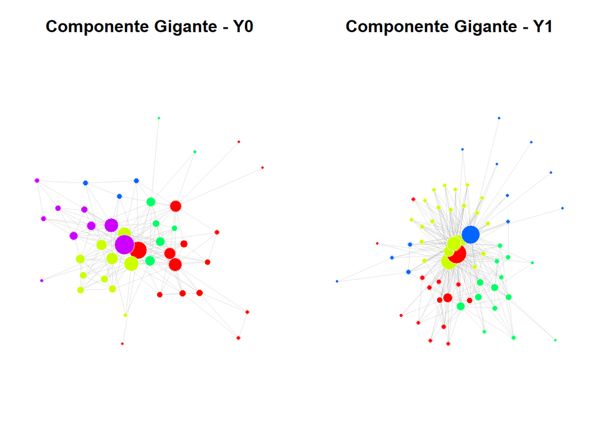

Visualmente, la componente gigante de $Y1$ presenta una estructura más compacta e integrada en comparación con $Y0$. Se observa una mayor concentración de conexiones alrededor de los nodos centrales y una menor dispersión relativa de los actores periféricos. Este comportamiento es consistente con las métricas estructurales obtenidas previamente, particularmente el aumento de la densidad y la reducción de la distancia geodésica promedio, lo que sugiere una mayor cohesión global de la red en $Y1$.

# 5.

Considere las acciones de tutela disponibles en la página de la Relatoría de la Corte Constitucional de Colombia (Relatoría de la Corte Constitucional). Según la Corte, los derechos más protegidos mediante tutelas son, en primer lugar, el derecho de petición, seguido del derecho a la salud y, finalmente, el derecho al debido proceso.

## a. Una vez en la pagina, en el buscador principal escriba derecho a la aslud y filtre la fecha para todas aquelas tutelas resueltas en el 2004 (fecha de providencia desde 01/01/2004) hasta el dia 13/12/24. Luego, incie la busqueda. En la parte izquierda de la pagina encontrara filtros adicionales. Asi, en la sección Providencia filtre por Tutela y a continuacion exporte los resultados en excel utilizando el boton verde que dice Exportar resultados en EXCEL. A la hora de hacer este proceso le deben resultar 158 providencias. CUando exporte los resultados escojola opcion Seleccionar Todas respecto a la informacion a exportar. Este proceso descargara en su computador un archivo con raiz “relatoria_corte_Constitucional” seguido por la fecha del dia de la descarga. ahora consolidar un archivo de texto plano en el que consigne todo el texto dado en la columna denominada “Resumen”.

Top 10 tokens más frecuentes

| word | n |
| --- | --- |
| salud | 297 |
| hecho | 92 |
| servicios | 91 |
| situacion | 90 |
| especial | 80 |
| laboral | 80 |
| relacionada | 75 |
| entidad | 72 |
| proceso | 66 |
| vulneracion | 66 |

## b. Repetir el procedimiento descrito en el numeral a. para “derecho de petición” en 2024.

Top 10 tokens más frecuentes

| word | n |
| --- | --- |
| salud | 106 |
| proceso | 91 |
| entidad | 84 |
| debido | 67 |
| laboral | 64 |
| situacion | 62 |
| hecho | 59 |
| relacionada | 58 |
| solicitud | 56 |
| actora | 54 |

## c. Repetir el procedimiento descrito en el numeral a. para “debido proceso” en 2024.

Top 10 tokens más frecuentes

| word | n |
| --- | --- |
| proceso | 226 |
| debido | 125 |
| decision | 84 |
| judicial | 71 |
| actora | 66 |
| entidad | 65 |
| administrativo | 62 |
| laboral | 61 |
| relacionada | 59 |
| tramite | 59 |

## d. Realizar un análisis exhaustivo del texto relacionado con estos derechos empleando técnicas de redes sociales (no es necesario hacer un análsis de sentimiento). Comparar los resultados obtenidos y presentarlos de manera clara y estructurada, destacando las similitudes, diferencias y patrones relevantes.

### Unigramas

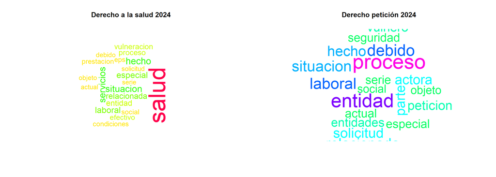

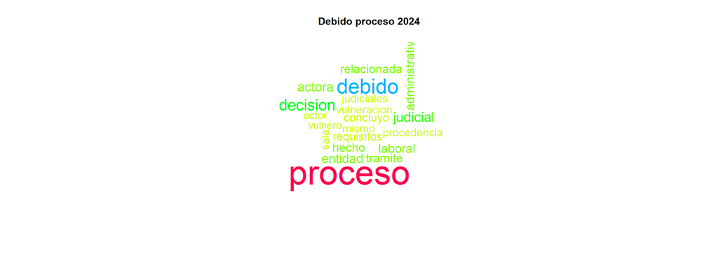

Adicionalmente, entre el derecho a la salud y el debido proceso se identifica la palabra “vulneración” como nexo; mientras que entre el derecho de petición y el debido proceso, el término compartido es “proceso”.

- **Salud:** en esta categoría destacan palabras como: **vulneración**, **situación**, **especial**, **laboral**, **EPS** y **prestación**. Estos términos resultan interesantes porque apuntan a la recurrencia de la **vulneración** del derecho a la **salud** en contextos **laborales**, asociada a la seguridad social, a personas en **condiciones especiales** y a posibles **prestaciones** de **servicios** por parte de una o varias **entidades**.
- **Petición:** podemos ver que se destaca **salud** y nuevamente aparece **laboral**, lo que nos puede indicar que se pudo haber **vulnerado** el derecho a la salud o no haber **hecho** un **debido** **proceso** por parte de una **entidad** o una parte **actora**.
- **Proceso:** en este caso encontramos más términos como **decisión judicial**, volevmos a encontrar **vulneración**, **entidad** y **laboral**, pero tambien encontramos **actor** y **actora**, entendiendose como que se puede llamar **actora** a una entidad o a una persona, siendo **actora** más frecuente.

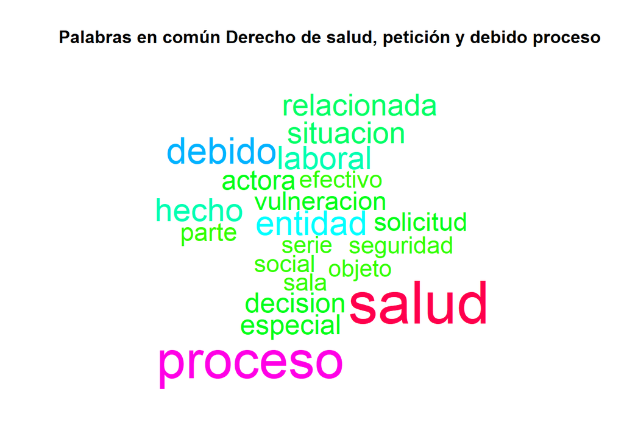

Acá ya observamos las palabras en común que tienen las tres temáticas de tutelas.

Destacan términos como salud, proceso, debido, entidad, hecho y laboral, lo que sugiere que existen elementos compartidos entre las tutelas analizadas, especialmente en relación con actuaciones institucionales, conflictos laborales y garantías procesales. Además, la presencia de palabras como debido y proceso refleja la estrecha relación entre el derecho de petición y el debido proceso dentro de este tipo de acciones constitucionales.

También puede observarse que, aunque cada temática posee vocabulario particular, el wordcloud evidencia un núcleo común asociado a la protección de derechos fundamentales y a las actuaciones de entidades encargadas de garantizar dichos derechos.

Frecuencia palabras en común

| word | salud | peticion | proceso |
| --- | --- | --- | --- |
| salud | 0.017 | 0.007 | 0.002 |
| hecho | 0.005 | 0.004 | 0.004 |
| servicios | 0.005 | 0.003 | 0.000 |
| situacion | 0.005 | 0.004 | 0.003 |
| laboral | 0.005 | 0.004 | 0.004 |
| especial | 0.005 | 0.003 | 0.003 |
| relacionada | 0.004 | 0.004 | 0.004 |
| entidad | 0.004 | 0.006 | 0.004 |
| proceso | 0.004 | 0.006 | 0.015 |
| vulneracion | 0.004 | 0.003 | 0.003 |

Algunas palabras presentan una mayor frecuencia en una temática de tutela que en otras. Por ejemplo, salud aparece con alta frecuencia en las tutelas relacionadas con el derecho a la salud, como era de esperarse, mientras que en las tutelas de debido proceso su aparición es mucho menor.

Sin embargo, para la mayoría de las palabras que no están directamente asociadas con una temática específica, las frecuencias son relativamente similares entre los tres tipos de tutela. Esto sugiere la existencia de un vocabulario compartido relacionado con procedimientos jurídicos, actuaciones de entidades y protección de derechos fundamentales, independientemente de la temática principal de la tutela.

Frecuencia palabras distintas

| word | n |
| --- | --- |
| abandonar | 3 |
| abordo | 3 |
| abstenerse | 3 |
| abstenga | 3 |
| abuela | 3 |
| abuelos | 3 |
| abuso | 3 |
| academica | 3 |
| academicas | 3 |
| academico | 3 |

Acá podemos notar ya palabras que pueden ser bastante específicas de un caso en particular.

Correlación vocabulario total

| comparacion | p_value | Estimacion |
| --- | --- | --- |
| salud vs peticion | 0 | 0.861 |
| salud vs proceso | 0 | 0.661 |
| proceso vs peticion | 0 | 0.834 |

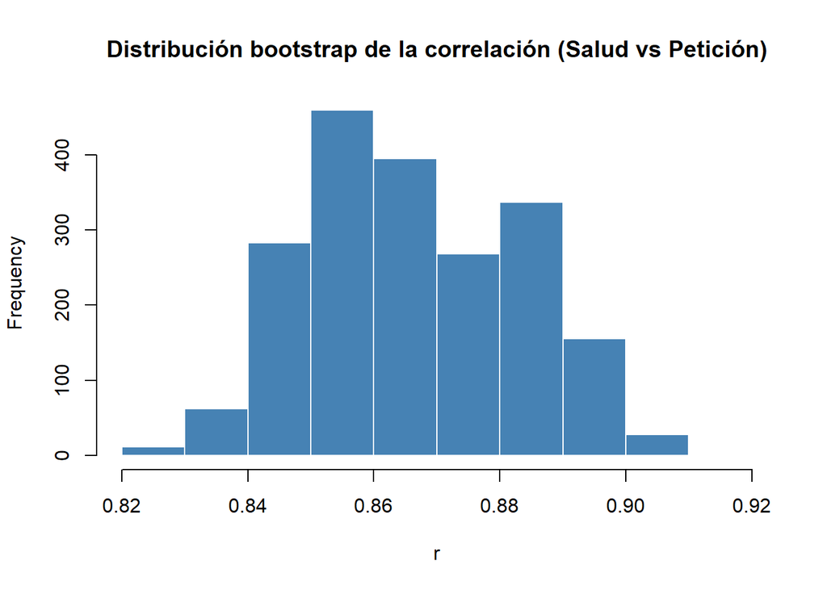

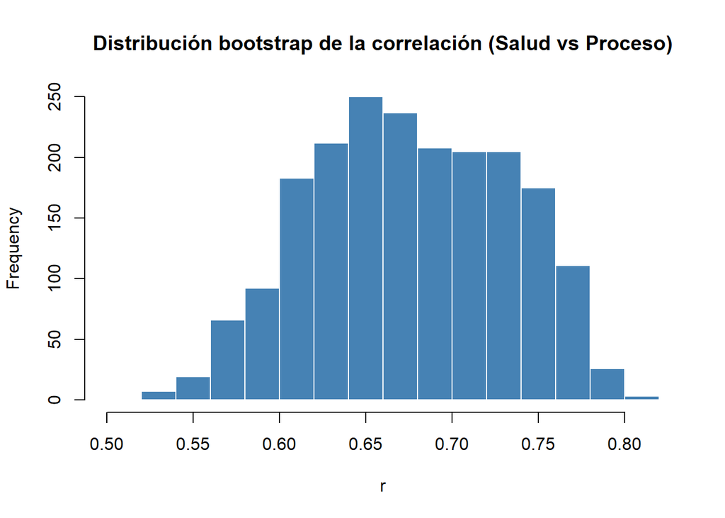

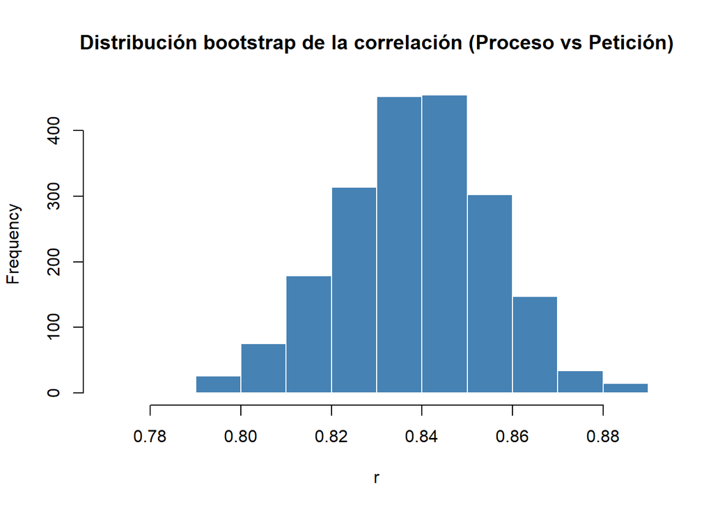

Correlación vocabulario total

| comparacion | Intervalo |
| --- | --- |
| salud vs peticion | 0.838,0.898 |
| salud vs proceso | 0.57,0.775 |
| proceso vs peticion | 0.805,0.87 |

- Podemos evidenciar correlaciones positivas moderadamente altas, como en el caso de salud y proceso, o altas para los demás casos, lo que nos indica que las palabras más frecuentes de un tema tambien suelen ser frecuentes en el otro.
- Además, se realizó un procedimiento de **bootstrap** con el fin de obtener una estimación más robusta de las correlaciones. En las simulaciones obtenidas, las correlaciones continuaron siendo positivas y de magnitud moderadamente alta o alta, respectivamente.
- Estos resultados refuerzan la idea de la existencia de un vocabulario general compartido entre las distintas temáticas de tutelas, asociado principalmente a términos jurídicos, institucionales y de protección de derechos fundamentales.

Correlación vocabulario en común

| comparacion | p_value | Estimacion |
| --- | --- | --- |
| salud vs peticion | 0 | 0.852 |
| salud vs proceso | 0 | 0.627 |
| proceso vs peticion | 0 | 0.824 |

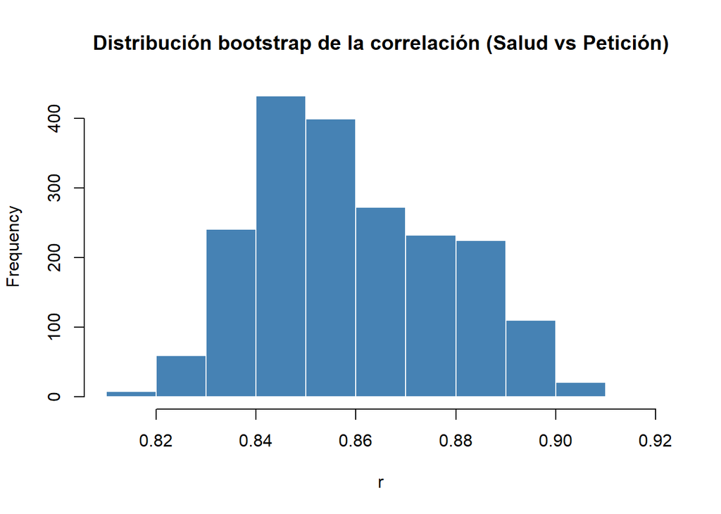

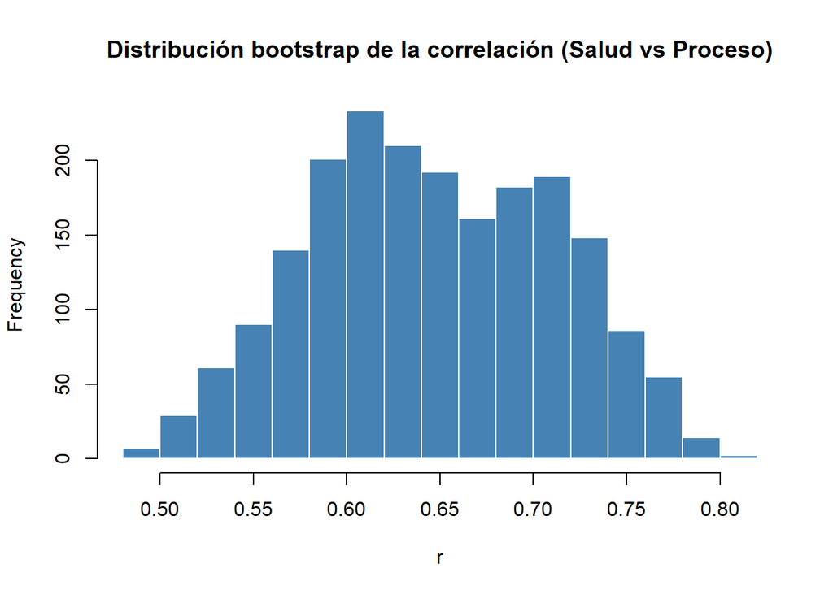

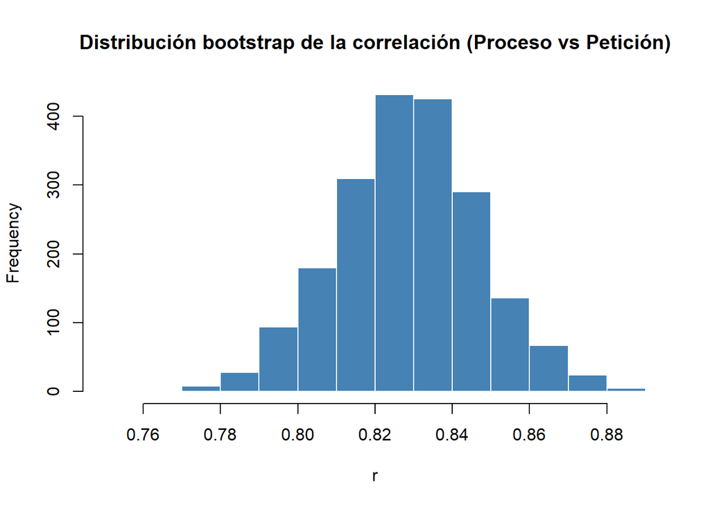

| comparacion | Intervalo |
| --- | --- |
| salud vs peticion | 0.829,0.897 |
| salud vs proceso | 0.525,0.765 |
| proceso vs peticion | 0.792,0.865 |

- Podemos evidenciar correlaciones positivas moderadamente altas, como en el caso de salud y proceso, o altas para los demás casos, lo que nos indica que las palabras más frecuentes de un tema tambien suelen ser frecuentes en el otro.
- Además, se realizó un procedimiento de **bootstrap** con el fin de obtener una estimación más robusta de las correlaciones. En las simulaciones obtenidas, las correlaciones continuaron siendo positivas y de magnitud moderadamente alta o alta, respectivamente.
- Las estimaciones son bastante similares a las del vocabulario general, esto sugiere que una parte importante de la correlación entre las temáticas se encuentra asociada a las palabras compartidas.

[figure not shown]

Se realizó un wordcloud con las palabras no compartidas entre las tres temáticas. Los colores asignados fueron azul para salud, verde para derecho de petición y naranja para debido proceso.

En este gráfico pueden observarse términos más característicos de cada temática. Por ejemplo, aparecen entidades como **INVIMA** en las tutelas relacionadas con salud, **VITRO** en derercho de petición e **ICETEX** en debido proceso. Esto evidencia que, aunque existe un vocabulario jurídico compartido entre las tutelas, cada temática también presenta términos y actores particulares asociados a problemáticas específicas de cada derecho.

### Bigramas

#### Salud

Top 10 bigramas más frecuentes

| word1 | word2 | weight |
| --- | --- | --- |
| carencia | actual | 48 |
| hecho | comun | 36 |
| seguridad | social | 35 |
| ninos | ninas | 32 |
| debido | proceso | 31 |
| estabilidad | laboral | 30 |
| hecho | superado | 25 |
| tratamiento | integral | 25 |
| medico | tratante | 23 |
| capacidad | laboral | 21 |

En las tutelas relacionadas con el derecho a la salud se observan bigramas asociados tanto a aspectos médicos como jurídicos y laborales. Expresiones como seguridad social, tratamiento integral y médico tratante reflejan solicitudes relacionadas con la prestación de servicios de salud y la garantía de tratamientos médicos.

Asimismo, aparecen términos como capacidad laboral y estabilidad laboral, lo que sugiere la presencia de conflictos entre condiciones de salud y derechos laborales de los accionantes.

Por otro lado, bigramas como debido proceso, hecho superado y carencia actual corresponden a expresiones frecuentes en el lenguaje jurídico de las sentencias de tutela, asociadas al análisis procesal realizado por los jueces. Finalmente, la aparición de niños niñas evidencia la relevancia de casos relacionados con sujetos de especial protección constitucional.

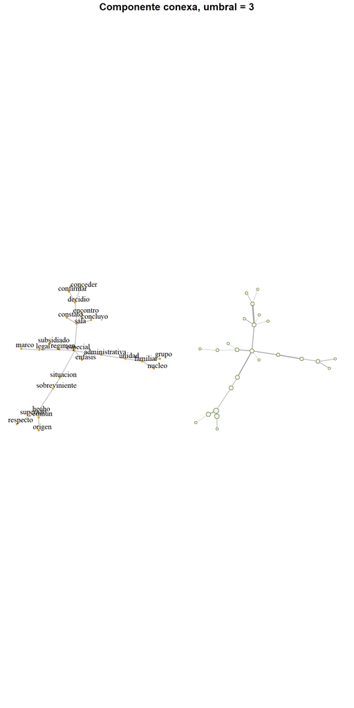

La existencia de una componente gigante indica que gran parte del vocabulario utilizado en las tutelas se encuentra interconectado, formando un núcleo común de términos que aparecen conjuntamente en múltiples documentos. Esto refleja una estructura temática relativamente cohesionada dentro de las tutelas de salud.

#### Peticion

Top 10 bigramas más frecuentes

| word1 | word2 | weight |
| --- | --- | --- |
| debido | proceso | 47 |
| carencia | actual | 38 |
| capacidad | laboral | 27 |
| seguridad | social | 27 |
| garantias | constitucionales | 24 |
| hecho | superado | 21 |
| proceso | administrativo | 21 |
| consulta | previa | 19 |
| hecho | comun | 17 |
| ninos | ninas | 15 |

En las tutelas relacionadas con el derecho de petición se observan bigramas asociados tanto a aspectos jurídicos como laborales. Expresiones como seguridad social y capacidad laboral, reflejan posibles solcitudes asociadas con el contexto laboral.

Por otro lado, bigramas como debido proceso, hecho superado y carencia actual corresponden a expresiones frecuentes en el lenguaje jurídico de las sentencias de tutela, asociadas al análisis procesal realizado por los jueces. Finalmente, la aparición de niños niñas evidencia la relevancia de casos relacionados con sujetos de especial protección constitucional.

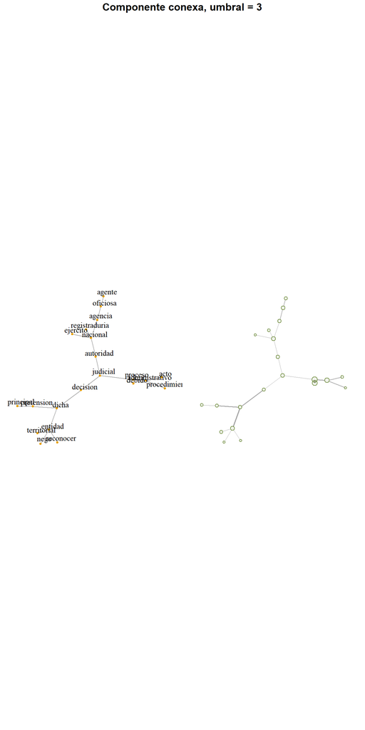

La existencia de una componente gigante refleja una estructura temática relativamente cohesionada dentro de las tutelas de derecho de petición, en esta subred se agrupan términos que coaparecen frecuentemente, lo que indica patrones discursivos recurrentes asociados a situaciones comunes del litigio, como procedimientos administrativos, actores institucionales y garantías jurídicas. En este caso, se observan nodos relacionados con entidades como la Registraduría y el Ejército, lo que podría reflejar la presencia de conflictos en los que intervienen instituciones públicas específicas dentro de solicitudes o reclamos administrativos.

#### Proceso

Top 10 bigramas más frecuentes

| word1 | word2 | weight |
| --- | --- | --- |
| debido | proceso | 109 |
| proceso | administrativo | 32 |
| providencias | judiciales | 28 |
| carencia | actual | 26 |
| garantias | constitucionales | 23 |
| seguridad | social | 22 |
| procedencia | excepcional | 21 |
| entidades | accionadas | 20 |
| capacidad | laboral | 19 |
| conflicto | armado | 17 |

La aparición del bigrama “conflicto armado” dentro de las tutelas asociadas al debido proceso es un hallazgo relevante, ya que sugiere la presencia de referencias al marco de conflicto armado como contexto jurídico o argumentativo. Esto puede estar relacionado con la aplicación de estándares reforzados de protección constitucional, particularmente en casos donde los accionantes son sujetos de especial protección o se invocan principios del derecho internacional humanitario o jurisprudencia constitucional sobre víctimas del conflicto.

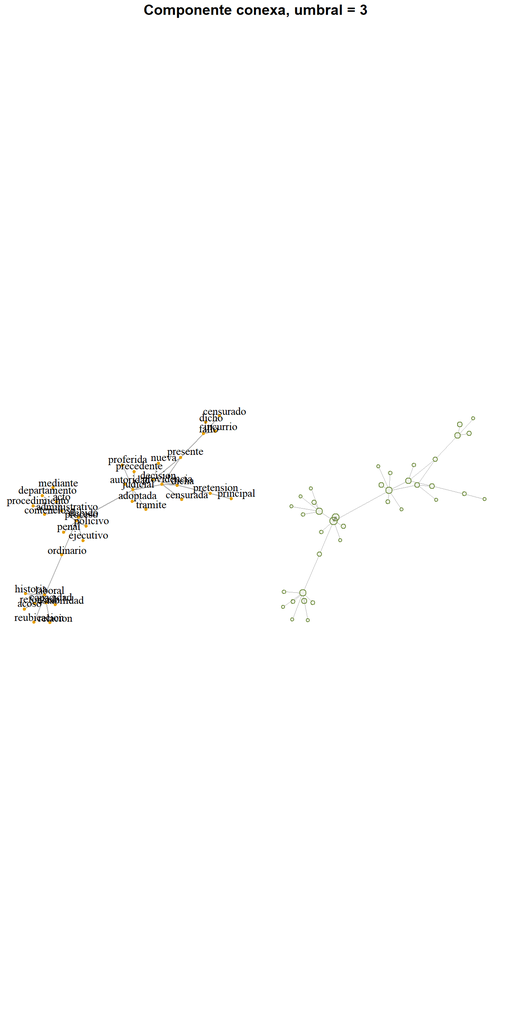

En esta subred se agrupan términos que coaparecen con alta frecuencia dentro de las tutelas asociadas al debido proceso, conformando un núcleo temático coherente. En ella se observan referencias a procesos penales, actuaciones policivas y providencias judiciales, lo que sugiere que el discurso no se limita a un único tipo de trámite, sino que abarca distintas esferas del sistema de justicia. La presencia de estos elementos puede indicar la coexistencia de múltiples niveles de intervención institucional dentro de las tutelas analizadas.

Resultados

| Medidas.departamento | salud | peticion | proceso |
| --- | --- | --- | --- |
| Distancia media | 21.110 | 17.044 | 26.345 |
| grado medio | 1.308 | 1.340 | 1.366 |
| Desviación estándar del grado | 0.756 | 0.770 | 0.999 |
| Número de clanes | 227.000 | 201.000 | 218.000 |
| Densidad | 0.004 | 0.004 | 0.004 |
| Transitividad | 0.000 | 0.000 | 0.037 |
| Asortatividad | -0.003 | -0.059 | -0.010 |

- En términos generales, las tres redes de bigramas (salud, petición y proceso) presentan patrones estructurales similares, con diferencias leves en sus métricas globales.
- En primer lugar, la distancia media sugiere que las palabras en las tutelas de derecho de petición tienden a estar ligeramente más cercanas entre sí en comparación con las redes de salud y debido proceso, lo que podría indicar una mayor proximidad temática en el lenguaje utilizado en este tipo de tutelas.
- En cuanto al grado medio, los valores son relativamente similares entre redes, lo que indica que, en promedio, cada nodo (palabra) mantiene un número comparable de conexiones en los tres casos. Asimismo, la baja densidad en todas las redes sugiere estructuras generales poco compactas, lo cual es consistente con redes de coocurrencia lingüística, donde no todas las palabras se conectan entre sí.
- La alta cantidad de cliques maximales (calculados mediante count_cliques_max) sugiere la presencia de múltiples subestructuras locales de alta cohesión, aunque sin formar una red global altamente integrada. Esto refuerza la idea de una organización fragmentada en microgrupos semánticos.
- La transitividad baja o nula en salud y petición, y ligeramente mayor en proceso, indica una escasa tendencia a la formación de triángulos completos, lo que sugiere que las asociaciones entre palabras son más lineales que transitivas.
- Finalmente, la asortatividad negativa o cercana a cero indica una leve tendencia (aunque débil) de que nodos con alto grado se conecten con nodos de bajo grado, lo que es consistente con redes lingüísticas donde existen términos altamente conectores (palabras funcionales o jurídicas frecuentes) que articulan vocabulario más específico o menos frecuente.

### Skipgramas

#### Salud

Top 10 skipgramas más frecuentes

| word1 | word2 | weight |
| --- | --- | --- |
| efectivo | goce | 50 |
| actual | objeto | 48 |
| carencia | actual | 48 |
| impartieron | serie | 42 |
| ninos | ninas | 37 |
| hecho | comun | 36 |
| seguridad | social | 35 |
| ninas | adolescentes | 32 |
| debido | proceso | 31 |
| estabilidad | laboral | 30 |

Entre los skipgramas más frecuentes destaca la coocurrencia “niñas – adolescentes”, lo que sugiere una presencia importante de referencias a menores de edad dentro de las tutelas de salud. Esto puede estar relacionado con el enfoque de especial protección constitucional que reciben niños, niñas y adolescentes en la jurisprudencia colombiana, especialmente en casos asociados al acceso a servicios médicos, tratamientos o garantías fundamentales.

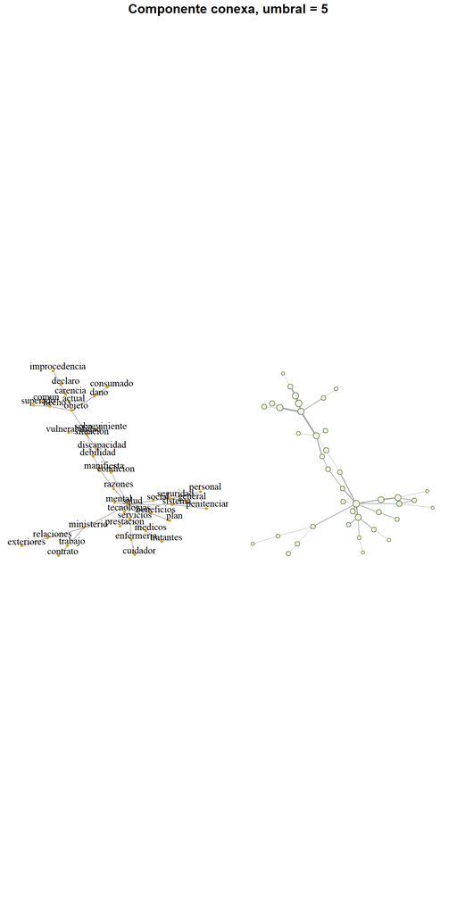

En la componente gigante de la red de skipgramas (con umbral 5) se observa una mayor presencia de términos asociados directamente al ámbito de la salud, en contraste con el vocabulario predominantemente jurídico identificado en otras redes. Destacan asociaciones como “salud – mental”, “enfermería – cuidador” y “ministerio – salud”, las cuales reflejan temáticas relacionadas con atención médica, cuidado de pacientes y participación institucional dentro del sistema de salud.

#### Peticion

Top 10 skipgramas más frecuentes

| word1 | word2 | weight |
| --- | --- | --- |
| debido | proceso | 47 |
| actual | objeto | 38 |
| carencia | actual | 38 |
| efectivo | goce | 37 |
| impartieron | serie | 32 |
| capacidad | laboral | 27 |
| perdida | capacidad | 27 |
| seguridad | social | 27 |
| garantias | constitucionales | 24 |
| hecho | superado | 21 |

En las tutelas de derecho de petición se observa una alta similitud entre los skipgramas y los bigramas más frecuentes, lo que sugiere que muchas de las asociaciones relevantes entre palabras aparecen de manera cercana y recurrente dentro del texto, sin necesidad de grandes separaciones entre términos.

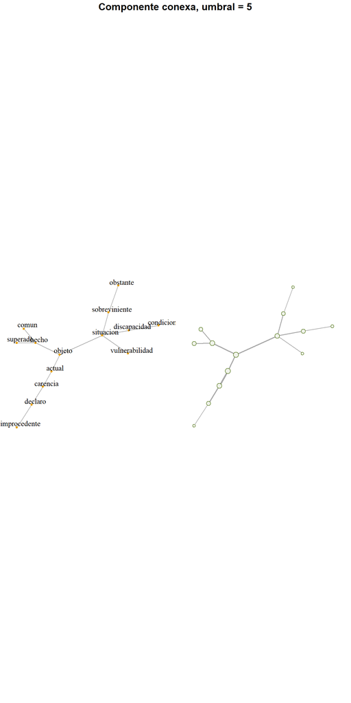

#### Proceso

Top 10 skipgramas más frecuentes

| word1 | word2 | weight |
| --- | --- | --- |
| debido | proceso | 109 |
| efectivo | goce | 33 |
| proceso | administrativo | 33 |
| debido | administrativo | 29 |
| providencias | judiciales | 28 |
| desconocimiento | precedente | 27 |
| impartieron | serie | 27 |
| actual | objeto | 26 |
| carencia | actual | 26 |
| garantias | constitucionales | 23 |

En las tutelas de debido proceso se observa una alta similitud entre los skipgramas y los bigramas más frecuentes, lo que sugiere que muchas de las asociaciones relevantes entre palabras aparecen de manera cercana y recurrente dentro del texto, sin necesidad de grandes separaciones entre términos.

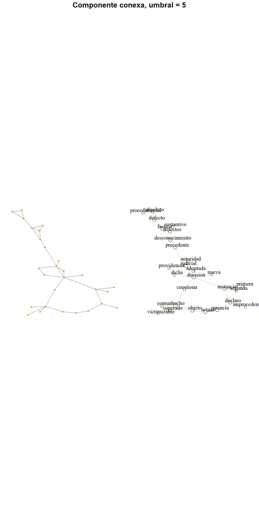

Resultados

| Medidas.departamento | salud | peticion | proceso |
| --- | --- | --- | --- |
| Distancia media | 56.793 | 27.984 | 34.911 |
| grado medio | 1.388 | 1.325 | 1.498 |
| Desviación estándar del grado | 0.862 | 0.681 | 0.981 |
| Número de clanes | 169.000 | 145.000 | 161.000 |
| Densidad | 0.005 | 0.006 | 0.006 |
| Transitividad | 0.074 | 0.117 | 0.159 |
| Asortatividad | 0.162 | 0.082 | 0.149 |

## e. Repetir el análisis para los años 2019, 2020, 2021, 2022 y 2023. *Importante:* al aplicar el filtro de fechas, asegúrese de abarcar todo el año completo para cada caso.

## f. Interpretar los resultados obtenidos.

### 2019

Top 10 tokens más frecuentes

| word | n |
| --- | --- |
| salud | 187 |
| laboral | 68 |
| situacion | 61 |
| concede | 60 |
| servicios | 59 |
| entidad | 57 |
| sala | 54 |
| proceso | 52 |
| eps | 51 |
| relacionada | 51 |

Top 10 tokens más frecuentes

| word | n |
| --- | --- |
| proceso | 76 |
| entidad | 74 |
| concede | 70 |
| salud | 54 |
| laboral | 52 |
| actor | 48 |
| peticion | 47 |
| sala | 46 |
| pension | 45 |
| reconocimiento | 45 |

Top 10 tokens más frecuentes

| word | n |
| --- | --- |
| proceso | 175 |
| debido | 95 |
| concede | 57 |
| laboral | 51 |
| administrativo | 50 |
| decision | 50 |
| entidad | 45 |
| judicial | 41 |
| actor | 39 |
| judiciales | 39 |

No obstante, se observan algunas particularidades temáticas. En las tutelas de salud aparece con mayor relevancia el término “EPS”, lo que podría reflejar una mayor centralidad de las entidades prestadoras de salud dentro de las controversias analizadas en 2019.

Por otro lado, en las tutelas de derecho de petición destaca la presencia de palabras como “pensión” y “reconocimiento”, lo que sugiere una posible concentración de solicitudes relacionadas con derechos pensionales y seguridad social.